# Angrist & Evans (1998) — Main Analysis

Reproduction tables, DML estimates, learner comparisons, and weight diagnostics

Alexander Unger

03 August 2026

# Setup

## Data & Design

**Setting.** Angrist and Evans (1998) childbearing application. The instrument is `samesex`; the treatment is `morekids`. The fixed diagnostic samples contain 3,000 observations for the primary labor outcome and 3,000 observations for the primary log-income outcome. They are created in `ae98_make_balanced_subsample_submission.Rmd`.

**Common covariate design.** Every estimator uses `agem`, `agefstm`, `sexk`, `blackm`, `hispm`, and `othracem`. The second-child sex indicator, `sex2nd`, is not included because, together with first-child sex, it deterministically reveals the instrument and creates exact collinearity within the instrument-specific nuisance regressions. The common six-variable design also makes the kappa, linear, forest, Ranger, and XGBoost comparisons use the same information set. Angrist and Evans report that removing the individual child-sex controls changes their estimates by no more than about two percent. See [Angrist and Evans (1998)](https://www.dpipe.tsukuba.ac.jp/~naito/teaching_web/public_economics_2013_web/Angrist_Evans_AER_1998.pdf).

Child-application analysis dimensions

| Outcome | N | Pr(Z=1) | Pr(D=1) | Covariates |
| --- | --- | --- | --- | --- |
| Work Status | 3000 | 0.505 | 0.402 | 6 |
| Maternal Log Income | 3000 | 0.503 | 0.348 | 6 |

# 1. Reproduction — SUW Table 4 (split by outcome family)

The two tables reproduce the recoding structure of SUW Table 4 on the fixed diagnostic subsamples. They are not intended to reproduce the published full-sample point estimates.

## Results

### Work Status

AE98 reproduction — Work Status

| Estimator | 1 if worked, 0 else | 2 if worked, 1 else | 1 if did not work, 0 else |
| --- | --- | --- | --- |
| **Panel A: 2SLS (HC1-robust)** |  |  |  |
| 2SLS | -0.095 (0.274) | -0.095 (0.274) | -0.095 (0.274) |
| **Panel B: Normalized kappa estimators** |  |  |  |
| τ_cb_u | -0.095 (0.274) | -0.095 (0.274) | -0.095 (0.274) |
| τ_ml_u | -0.094 (0.274) | -0.094 (0.274) | -0.094 (0.274) |
| τ_ml_a10 | -0.094 (0.274) | -0.094 (0.274) | -0.094 (0.274) |
| **Panel C: Unnormalized kappa estimators** |  |  |  |
| τ_ml_a | -0.094 (0.274) | -0.094 (0.274) | -0.095 (0.274) |
| τ_ml_t | -0.094 (0.274) | -0.094 (0.274) | -0.095 (0.274) |
| τ_ml_a0 | -0.094 (0.274) | -0.094 (0.274) | -0.095 (0.274) |

Note:  
Diagnostic subsample, N = 3000; SUW Table 4 uses N = 394,840. Each cell reports estimate with SE below. Blue rows are normalized; orange rows are unnormalized. The ‘did not work’ column follows SUW’s reflected-outcome display convention by reversing the estimate sign while leaving the SE unchanged. Stars: * p<0.10, ** p<0.05, *** p<0.01.

### Maternal Log Income

AE98 reproduction — Maternal Log Income

| Estimator | Cents | Dollars | $1000s | $100,000s |
| --- | --- | --- | --- | --- |
| **Panel A: 2SLS (HC1-robust)** |  |  |  |  |
| 2SLS | -0.182 (0.755) | -0.182 (0.755) | -0.182 (0.755) | -0.182 (0.755) |
| **Panel B: Normalized kappa estimators** |  |  |  |  |
| τ_cb_u | -0.182 (0.754) | -0.182 (0.754) | -0.182 (0.754) | -0.182 (0.754) |
| τ_ml_u | -0.182 (0.755) | -0.182 (0.755) | -0.182 (0.755) | -0.182 (0.755) |
| τ_ml_a10 | -0.182 (0.755) | -0.182 (0.755) | -0.182 (0.755) | -0.182 (0.755) |
| **Panel C: Unnormalized kappa estimators** |  |  |  |  |
| τ_ml_a | -0.174 (0.755) | -0.177 (0.755) | -0.180 (0.755) | -0.183 (0.755) |
| τ_ml_t | -0.174 (0.755) | -0.177 (0.755) | -0.180 (0.754) | -0.183 (0.754) |
| τ_ml_a0 | -0.174 (0.755) | -0.177 (0.755) | -0.181 (0.755) | -0.183 (0.755) |

Note:  
Diagnostic subsample, N = 3000; SUW Table 4 uses N = 220,502. Each cell reports estimate with SE below. Blue rows are normalized; orange rows are unnormalized. Common covariates: agem, agefstm, sexk, blackm, hispm, othracem. Stars: * p<0.10, ** p<0.05, *** p<0.01.

# 2. Double ML — PLR-IV & Wald-AIPW (honest forest, tuned vs. untuned)

Each outcome-specific sample is fitted with untuned (`tune.parameters = "none"`) and tuned (`"all"`) honest forests. All four fits use five cross-fitting folds and seed 42.

## Estimates

### Work Status

Work Status — untuned honest forest (tune.parameters = “none”)

| Estimator | Estimate | Standard Error | ω′Y reproduces τ̂ |
| --- | --- | --- | --- |
| PLR-IV | -0.1705 | 0.2475 | TRUE |
| Wald-AIPW | -0.1605 | 0.2624 | TRUE |

Note:  
Numerical reproduction follows the all.equal() check with R’s default tolerance.

Work Status — tuned honest forest (tune.parameters = “all”)

| Estimator | Estimate | Standard Error | ω′Y reproduces τ̂ |
| --- | --- | --- | --- |
| PLR-IV | -0.1174 | 0.2695 | TRUE |
| Wald-AIPW | -0.1007 | 0.2737 | TRUE |

Note:  
Numerical reproduction follows the all.equal() check with R’s default tolerance.

### Maternal Log Income

Maternal Log Income — untuned honest forest (tune.parameters = “none”)

| Estimator | Estimate | Standard Error | ω′Y reproduces τ̂ |
| --- | --- | --- | --- |
| PLR-IV | -0.2045 | 0.7631 | TRUE |
| Wald-AIPW | -0.2256 | 0.8023 | TRUE |

Note:  
Numerical reproduction follows the all.equal() check with R’s default tolerance.

Maternal Log Income — tuned honest forest (tune.parameters = “all”)

| Estimator | Estimate | Standard Error | ω′Y reproduces τ̂ |
| --- | --- | --- | --- |
| PLR-IV | -0.2480 | 0.7663 | TRUE |
| Wald-AIPW | -0.2379 | 0.7921 | TRUE |

Note:  
Numerical reproduction follows the all.equal() check with R’s default tolerance.

## DML vs. Kappa — Point Estimates

Tuned honest-forest DML versus normalized kappa estimates

| Estimator | Work Status | Maternal Log Income |
| --- | --- | --- |
| **Double ML** |  |  |
| PLR-IV (DML; tuned honest forest) | -0.117 (0.269) | -0.248 (0.766) |
| Wald-AIPW (DML; tuned honest forest) | -0.101 (0.274) | -0.238 (0.792) |
| **Kappa reference** |  |  |
| τ_cb_u (kappa, ref) | -0.095 (0.274) | -0.182 (0.754) |
| τ_ml_u (kappa, ref) | -0.094 (0.274) | -0.182 (0.755) |

Note:  
Each cell reports estimate (SE). All estimators use the common six-covariate specification.

# 3. Learner Comparison — PLR-IV and Wald-AIPW

The comparison uses the same learner families as Vietnam and Card. Every learner is fitted on the common six-covariate design introduced above, so differences are not confounded by learner-specific covariate sets.

## Estimates

### Work Status

Learner comparison — Work Status

| Estimator | Work Status |
| --- | --- |
| **PLR-IV** |  |
| PLR-IV (OLS) | -0.102 (0.272) |
| PLR-IV (ranger) | -0.148 (0.255) |
| PLR-IV (XGBoost tuned) | -0.129 (0.266) |
| **Wald-AIPW** |  |
| Wald-AIPW (linear+logit) | -0.104 (0.275) |
| Wald-AIPW (ranger) | -0.163 (0.265) |
| Wald-AIPW (XGBoost tuned) | -0.117 (0.267) |
| **Kappa reference** |  |
| τ_cb_u (kappa, ref) | -0.095 (0.274) |
| τ_ml_u (kappa, ref) | -0.094 (0.274) |

Note:  
Cells report estimate (SE). XGBoost rows use the stored fold-specifically tuned fits. All estimators use the common six-covariate specification.

### Maternal Log Income

Learner comparison — Maternal Log Income

| Estimator | Maternal Log Income |
| --- | --- |
| **PLR-IV** |  |
| PLR-IV (OLS) | -0.214 (0.761) |
| PLR-IV (ranger) | -0.250 (0.744) |
| PLR-IV (XGBoost tuned) | -0.263 (0.718) |
| **Wald-AIPW** |  |
| Wald-AIPW (linear+logit) | -0.217 (0.775) |
| Wald-AIPW (ranger) | -0.259 (0.752) |
| Wald-AIPW (XGBoost tuned) | -0.341 (0.753) |
| **Kappa reference** |  |
| τ_cb_u (kappa, ref) | -0.182 (0.754) |
| τ_ml_u (kappa, ref) | -0.182 (0.755) |

Note:  
Cells report estimate (SE). XGBoost rows use the stored fold-specifically tuned fits. All estimators use the common six-covariate specification.

# 4. Weight Diagnostics

The same candidate registry is used for the summary statistics, ESS and sign-cancellation results, and Love plots. Algebraic kappa weights and DML vectors that reproduce their fitted estimates are eligible. The honest-forest entries use the tuned fits; untuned fits remain in the tuning comparison.

## Outcome-Weight Summary Statistics

The tables report statistics for the overall vector and its treated and sign-oriented control components. `Neg. share` is the fraction of observations with a negative oriented weight and differs from the absolute-mass sign-cancellation measure reported below. Only eligible representations are included.

### Work Status

Outcome-weight summary statistics — Work Status

| Scope | Outcome-weight summary statistics Min | Outcome-weight summary statistics Max | Outcome-weight summary statistics Neg. share | Outcome-weight summary statistics ΣTop10% | Outcome-weight summary statistics Σω | Outcome-weight summary statistics Σ\|ω\| |
| --- | --- | --- | --- | --- | --- | --- |
| **PLR-IV, tuned forest** |  |  |  |  |  |  |
| Overall | -0.0133101 | 0.0123865 | 0.4950 | 3.263880 | 0.0000000 | 30.33563 |
| Treated | -0.0122567 | 0.0123865 | 0.4573 | 1.315504 | 0.9734070 | 12.15355 |
| Control | -0.0121695 | 0.0133101 | 0.4797 | 2.009058 | 0.9734070 | 18.18207 |
| **Wald-AIPW, tuned forest** |  |  |  |  |  |  |
| Overall | -0.0135854 | 0.0119466 | 0.4950 | 3.226849 | 0.0000000 | 30.64797 |
| Treated | -0.0125972 | 0.0117713 | 0.4573 | 1.297115 | 0.9605903 | 12.26634 |
| Control | -0.0119466 | 0.0135854 | 0.4797 | 2.065856 | 0.9605903 | 18.38163 |
| **PLR-IV, linear** |  |  |  |  |  |  |
| Overall | -0.0127816 | 0.0131806 | 0.4950 | 3.264627 | 0.0000000 | 30.62337 |
| Treated | -0.0120027 | 0.0131806 | 0.4573 | 1.322534 | 1.0000000 | 12.28742 |
| Control | -0.0127248 | 0.0127816 | 0.4797 | 2.003181 | 1.0000000 | 18.33595 |
| **Wald-AIPW, linear/logit** |  |  |  |  |  |  |
| Overall | -0.0127313 | 0.0131673 | 0.4950 | 3.283378 | 0.0000000 | 30.83434 |
| Treated | -0.0119687 | 0.0131673 | 0.4573 | 1.329174 | 1.0066803 | 12.36249 |
| Control | -0.0126196 | 0.0127313 | 0.4797 | 2.021868 | 1.0066803 | 18.47185 |
| **PLR-IV, ranger** |  |  |  |  |  |  |
| Overall | -0.0170953 | 0.0189939 | 0.4950 | 3.516173 | 0.0000000 | 28.72313 |
| Treated | -0.0170953 | 0.0189939 | 0.4573 | 1.433697 | 0.9800604 | 11.53740 |
| Control | -0.0168529 | 0.0161362 | 0.4797 | 2.162272 | 0.9800604 | 17.18573 |
| **Wald-AIPW, ranger** |  |  |  |  |  |  |
| Overall | -0.0217710 | 0.0218231 | 0.4950 | 3.600237 | 0.0000000 | 29.24256 |
| Treated | -0.0217710 | 0.0218231 | 0.4573 | 1.471025 | 0.9890947 | 11.73806 |
| Control | -0.0216313 | 0.0206767 | 0.4797 | 2.241079 | 0.9890947 | 17.50450 |
| **τ_cb_u (kappa, CBPS)** |  |  |  |  |  |  |
| Overall | -0.0115139 | 0.0112694 | 0.4950 | 3.171056 | 0.0000000 | 30.88535 |
| Treated | -0.0114335 | 0.0112694 | 0.4573 | 1.282612 | 1.0000000 | 12.39523 |
| Control | -0.0112616 | 0.0115139 | 0.4797 | 1.959647 | 1.0000000 | 18.49012 |
| **τ_ml_u (kappa, MLE)** |  |  |  |  |  |  |
| Overall | -0.0115145 | 0.0112717 | 0.4950 | 3.171038 | 0.0000000 | 30.88334 |
| Treated | -0.0114337 | 0.0112717 | 0.4573 | 1.282614 | 1.0000000 | 12.39443 |
| Control | -0.0112637 | 0.0115145 | 0.4797 | 1.959627 | 1.0000000 | 18.48891 |
| **τ_ml_a10 (kappa, MLE)** |  |  |  |  |  |  |
| Overall | -0.0115174 | 0.0112698 | 0.4950 | 3.171235 | 0.0000000 | 30.88608 |
| Treated | -0.0114315 | 0.0112698 | 0.4573 | 1.282402 | 1.0000000 | 12.39221 |
| Control | -0.0112669 | 0.0115174 | 0.4797 | 1.960125 | 1.0000000 | 18.49387 |
| **τ_ml_a (kappa, MLE)** |  |  |  |  |  |  |
| Overall | -0.0115150 | 0.0112725 | 0.4950 | 3.171255 | 0.0004486 | 30.88501 |
| Treated | -0.0114342 | 0.0112725 | 0.4573 | 1.282702 | 1.0002342 | 12.39511 |
| Control | -0.0112644 | 0.0115150 | 0.4797 | 1.959705 | 0.9997855 | 18.48990 |
| **τ_ml_t (kappa, MLE)** |  |  |  |  |  |  |
| Overall | -0.0115123 | 0.0112698 | 0.4950 | 3.170513 | 0.0004485 | 30.87778 |
| Treated | -0.0114315 | 0.0112698 | 0.4573 | 1.282402 | 1.0000000 | 12.39221 |
| Control | -0.0112618 | 0.0115123 | 0.4797 | 1.959246 | 0.9995515 | 18.48557 |
| **τ_ml_a0 (kappa, MLE)** |  |  |  |  |  |  |
| Overall | -0.0115174 | 0.0112749 | 0.4950 | 3.171936 | 0.0004487 | 30.89164 |
| Treated | -0.0114366 | 0.0112749 | 0.4573 | 1.282978 | 1.0004487 | 12.39777 |
| Control | -0.0112669 | 0.0115174 | 0.4797 | 1.960125 | 1.0000000 | 18.49387 |

Note:  
Control rows use the sign-flipped −ω convention. ΣTop10% is the sum of the largest ten percent of weights within the row. Only algebraic or numerically verified representations are included.

### Maternal Log Income

Outcome-weight summary statistics — Maternal Log Income

| Scope | Outcome-weight summary statistics Min | Outcome-weight summary statistics Max | Outcome-weight summary statistics Neg. share | Outcome-weight summary statistics ΣTop10% | Outcome-weight summary statistics Σω | Outcome-weight summary statistics Σ\|ω\| |
| --- | --- | --- | --- | --- | --- | --- |
| **PLR-IV, tuned forest** |  |  |  |  |  |  |
| Overall | -0.0138730 | 0.0135748 | 0.4973 | 3.610538 | 0.0000000 | 34.16809 |
| Treated | -0.0137031 | 0.0135748 | 0.4593 | 1.267174 | 0.9685118 | 11.85111 |
| Control | -0.0133894 | 0.0138730 | 0.4824 | 2.415116 | 0.9685118 | 22.31698 |
| **Wald-AIPW, tuned forest** |  |  |  |  |  |  |
| Overall | -0.0143850 | 0.0140750 | 0.4973 | 3.734674 | 0.0000000 | 35.03252 |
| Treated | -0.0143850 | 0.0132712 | 0.4593 | 1.307957 | 0.9831007 | 12.13559 |
| Control | -0.0140750 | 0.0143238 | 0.4824 | 2.474620 | 0.9831007 | 22.89693 |
| **PLR-IV, linear** |  |  |  |  |  |  |
| Overall | -0.0148881 | 0.0159359 | 0.4973 | 3.724153 | 0.0000000 | 33.95520 |
| Treated | -0.0144022 | 0.0159359 | 0.4593 | 1.319286 | 1.0000000 | 11.81953 |
| Control | -0.0154873 | 0.0148881 | 0.4824 | 2.475610 | 1.0000000 | 22.13567 |
| **Wald-AIPW, linear/logit** |  |  |  |  |  |  |
| Overall | -0.0153040 | 0.0160165 | 0.4973 | 3.755176 | 0.0000000 | 34.27208 |
| Treated | -0.0144105 | 0.0160165 | 0.4593 | 1.331042 | 1.0103495 | 11.92090 |
| Control | -0.0153788 | 0.0153040 | 0.4824 | 2.510025 | 1.0103495 | 22.35119 |
| **PLR-IV, ranger** |  |  |  |  |  |  |
| Overall | -0.0216684 | 0.0186964 | 0.4973 | 4.044740 | 0.0000000 | 32.96110 |
| Treated | -0.0201347 | 0.0179921 | 0.4593 | 1.442987 | 0.9885579 | 11.42368 |
| Control | -0.0186964 | 0.0216684 | 0.4824 | 2.697123 | 0.9885579 | 21.53742 |
| **Wald-AIPW, ranger** |  |  |  |  |  |  |
| Overall | -0.0244892 | 0.0193676 | 0.4973 | 3.944614 | 0.0000000 | 32.25217 |
| Treated | -0.0217581 | 0.0181223 | 0.4593 | 1.414440 | 0.9806493 | 11.17840 |
| Control | -0.0193676 | 0.0244892 | 0.4824 | 2.686277 | 0.9806493 | 21.07377 |
| **τ_cb_u (kappa, CBPS)** |  |  |  |  |  |  |
| Overall | -0.0126823 | 0.0120153 | 0.4973 | 3.477084 | 0.0000000 | 33.56515 |
| Treated | -0.0126823 | 0.0120153 | 0.4593 | 1.223635 | 1.0000000 | 11.66920 |
| Control | -0.0119831 | 0.0126768 | 0.4824 | 2.327328 | 1.0000000 | 21.89595 |
| **τ_ml_u (kappa, MLE)** |  |  |  |  |  |  |
| Overall | -0.0126819 | 0.0120153 | 0.4973 | 3.477360 | 0.0000000 | 33.57014 |
| Treated | -0.0126819 | 0.0120153 | 0.4593 | 1.223722 | 1.0000000 | 11.67092 |
| Control | -0.0119831 | 0.0126778 | 0.4824 | 2.327485 | 1.0000000 | 21.89922 |
| **τ_ml_a10 (kappa, MLE)** |  |  |  |  |  |  |
| Overall | -0.0126820 | 0.0120132 | 0.4973 | 3.477674 | 0.0000000 | 33.57565 |
| Treated | -0.0126793 | 0.0120132 | 0.4593 | 1.223513 | 1.0000000 | 11.66875 |
| Control | -0.0119875 | 0.0126820 | 0.4824 | 2.328267 | 1.0000000 | 21.90691 |
| **τ_ml_a (kappa, MLE)** |  |  |  |  |  |  |
| Overall | -0.0126825 | 0.0120162 | 0.4973 | 3.477634 | 0.0005392 | 33.57224 |
| Treated | -0.0126825 | 0.0120162 | 0.4593 | 1.223819 | 1.0002501 | 11.67167 |
| Control | -0.0119841 | 0.0126784 | 0.4824 | 2.327593 | 0.9997109 | 21.90057 |
| **τ_ml_t (kappa, MLE)** |  |  |  |  |  |  |
| Overall | -0.0126793 | 0.0120132 | 0.4973 | 3.476764 | 0.0005391 | 33.56385 |
| Treated | -0.0126793 | 0.0120132 | 0.4593 | 1.223513 | 1.0000000 | 11.66875 |
| Control | -0.0119811 | 0.0126752 | 0.4824 | 2.327011 | 0.9994609 | 21.89510 |
| **τ_ml_a0 (kappa, MLE)** |  |  |  |  |  |  |
| Overall | -0.0126861 | 0.0120197 | 0.4973 | 3.478639 | 0.0005394 | 33.58195 |
| Treated | -0.0126861 | 0.0120197 | 0.4593 | 1.224173 | 1.0005394 | 11.67504 |
| Control | -0.0119875 | 0.0126820 | 0.4824 | 2.328267 | 1.0000000 | 21.90691 |

Note:  
Control rows use the sign-flipped −ω convention. ΣTop10% is the sum of the largest ten percent of weights within the row. Only algebraic or numerically verified representations are included.

## ESS and Sign-Cancellation Extension

Modified ESS is reported separately for treated and control observations and relative to the observed size of each treatment arm. Opposite-sign mass is the percentage of absolute weight mass with the opposite orientation within the respective arm. It measures sign cancellation rather than the number of negative observations.

### Work Status

Modified ESS and sign cancellation — Work Status

| Estimator | ESS mod T/C | ESS mod/N T/C | Opposite-sign mass T/C (%) |
| --- | --- | --- | --- |
| PLR-IV, tuned forest | 1201 / 1787 | 0.997 / 0.996 | 46.0 / 47.3 |
| Wald-AIPW, tuned forest | 1201 / 1788 | 0.997 / 0.996 | 46.1 / 47.4 |
| PLR-IV, linear | 1202 / 1789 | 0.997 / 0.997 | 45.9 / 47.3 |
| Wald-AIPW, linear/logit | 1202 / 1789 | 0.997 / 0.997 | 45.9 / 47.3 |
| PLR-IV, ranger | 1171 / 1745 | 0.972 / 0.972 | 45.8 / 47.1 |
| Wald-AIPW, ranger | 1170 / 1744 | 0.971 / 0.971 | 45.8 / 47.2 |
| τ_cb_u (kappa, CBPS) | 1204 / 1793 | 0.999 / 0.999 | 46.0 / 47.3 |
| τ_ml_u (kappa, MLE) | 1204 / 1793 | 0.999 / 0.999 | 46.0 / 47.3 |
| τ_ml_a10 (kappa, MLE) | 1204 / 1793 | 0.999 / 0.999 | 46.0 / 47.3 |
| τ_ml_a (kappa, MLE) | 1204 / 1793 | 0.999 / 0.999 | 46.0 / 47.3 |
| τ_ml_t (kappa, MLE) | 1204 / 1793 | 0.999 / 0.999 | 46.0 / 47.3 |
| τ_ml_a0 (kappa, MLE) | 1204 / 1793 | 0.999 / 0.999 | 46.0 / 47.3 |

Note:  
T/C denotes treated / sign-oriented control. Only algebraic or numerically verified representations are included.

### Maternal Log Income

Modified ESS and sign cancellation — Maternal Log Income

| Estimator | ESS mod T/C | ESS mod/N T/C | Opposite-sign mass T/C (%) |
| --- | --- | --- | --- |
| PLR-IV, tuned forest | 1041 / 1952 | 0.998 / 0.998 | 45.9 / 47.8 |
| Wald-AIPW, tuned forest | 1041 / 1952 | 0.998 / 0.998 | 45.9 / 47.9 |
| PLR-IV, linear | 1037 / 1946 | 0.995 / 0.994 | 45.8 / 47.7 |
| Wald-AIPW, linear/logit | 1037 / 1946 | 0.994 / 0.994 | 45.8 / 47.7 |
| PLR-IV, ranger | 1015 / 1905 | 0.973 / 0.974 | 45.7 / 47.7 |
| Wald-AIPW, ranger | 1016 / 1904 | 0.974 / 0.973 | 45.6 / 47.7 |
| τ_cb_u (kappa, CBPS) | 1042 / 1955 | 0.999 / 0.999 | 45.7 / 47.7 |
| τ_ml_u (kappa, MLE) | 1042 / 1955 | 0.999 / 0.999 | 45.7 / 47.7 |
| τ_ml_a10 (kappa, MLE) | 1042 / 1955 | 0.999 / 0.999 | 45.7 / 47.7 |
| τ_ml_a (kappa, MLE) | 1042 / 1955 | 0.999 / 0.999 | 45.7 / 47.7 |
| τ_ml_t (kappa, MLE) | 1042 / 1955 | 0.999 / 0.999 | 45.7 / 47.7 |
| τ_ml_a0 (kappa, MLE) | 1042 / 1955 | 0.999 / 0.999 | 45.7 / 47.7 |

Note:  
T/C denotes treated / sign-oriented control. Only algebraic or numerically verified representations are included.

# 5. Love Plots

Panels report absolute mean differences. Continuous covariates are standardized; binary covariates remain on the raw 0/1 scale. Only candidates that pass the representation gate are plotted.

## DML vs. Kappa

### Work Status

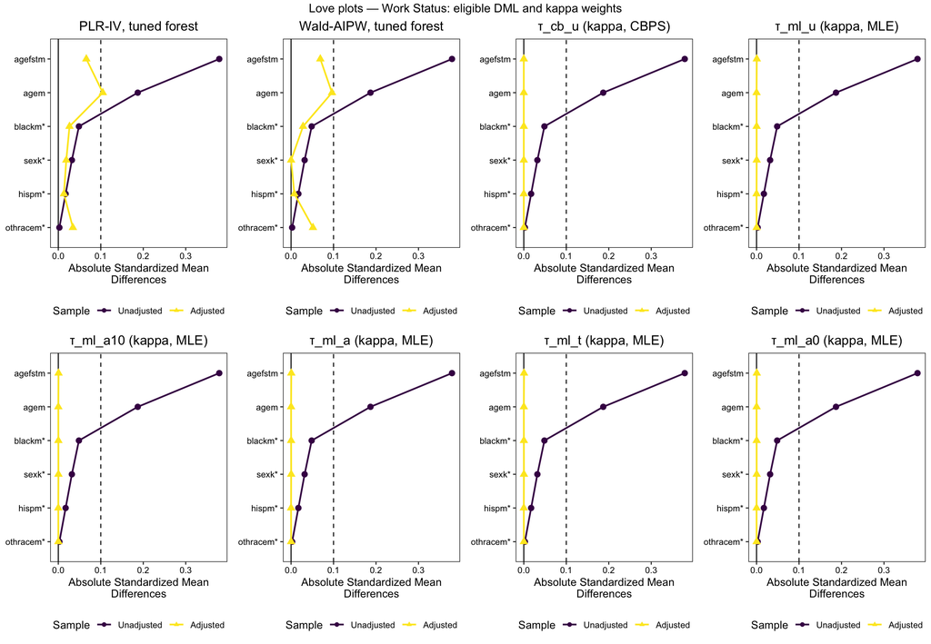

### Maternal Log Income

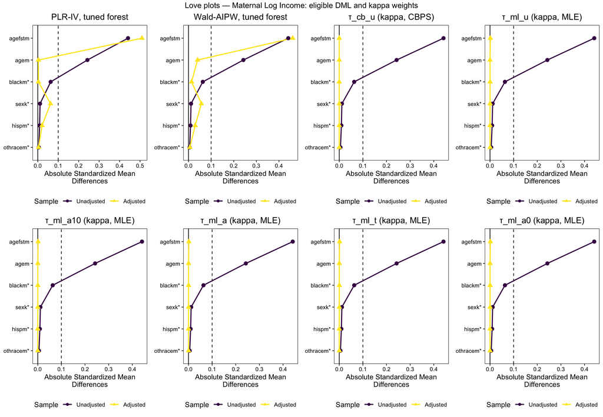

## Learners vs. Kappa

### Work Status

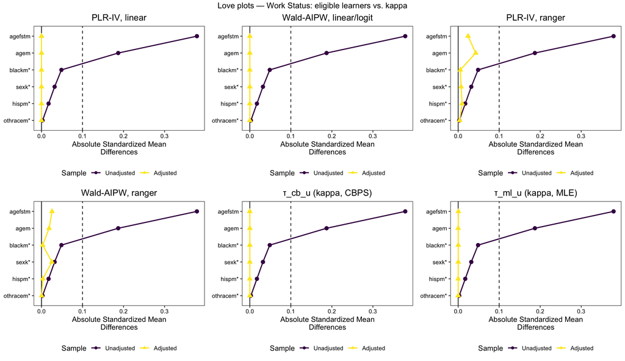

### Maternal Log Income

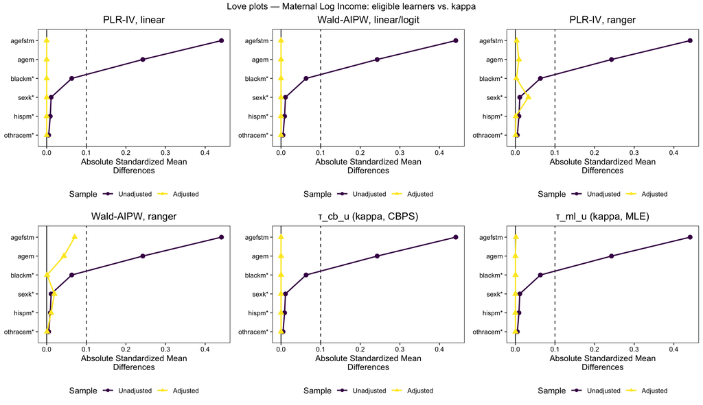

Only exact outcome-weight representations enter the figures. XGBoost remains an estimate-level learner comparison when its reconstructed vectors fail the reproduction check.